# International News Analysis: Approach Validations

Allan Sales

## Context

- International Media Bias
- Foreigner events are also important for our countries
- Media has great influence on people’s opinions
- Subjectivity rates might indicate whether media is biased or not

## Current Problem

- News are published in distinct languages
- We can’t directly compare rates from distinct languages

## Goal

- Fairly compare news subjectivities of distinct languages.

## Tools

- News from different publishers around the world
  - EventRegistry Dataset: Political news about Venezuela and Syrian
    - Pro: topic specific. We can draw conclusions about media bias regarding a topic
    - Con: small sample of opinion articles

```
## # A tibble: 10 x 3
## # Groups:   lang [5]
##    lang  opinative     n
##    <chr> <lgl>     <dbl>
##  1 deu   FALSE      2892
##  2 deu   TRUE         21
##  3 eng   FALSE     24769
##  4 eng   TRUE        315
##  5 ita   FALSE       468
##  6 ita   TRUE         11
##  7 por   FALSE      4494
##  8 por   TRUE         64
##  9 spa   FALSE      5858
## 10 spa   TRUE        151
```

- Webhose Dataset: Random news articles of random sections from distinct publishers
  - Pro: larger sample of opinion articles
  - Con: random topics. We can’t draw conclusions about media bias regarding a topic

```
## # A tibble: 10 x 3
## # Groups:   lang [5]
##    lang  opinative     n
##    <chr> <lgl>     <dbl>
##  1 deu   FALSE      1200
##  2 deu   TRUE       1200
##  3 eng   FALSE      1200
##  4 eng   TRUE       1200
##  5 ita   FALSE      1200
##  6 ita   TRUE       1200
##  7 por   FALSE      1200
##  8 por   TRUE       1200
##  9 spa   FALSE      1200
## 10 spa   TRUE       1200
```

- Subjectivity lexicons in Portuguese

## Methodology Architecture

- Two steps
  - Subjectivity rate computation
  - Rates normalization

Starting from the end:

### Rates normalization

- comparable rates: how much the news rates differs from the references rates

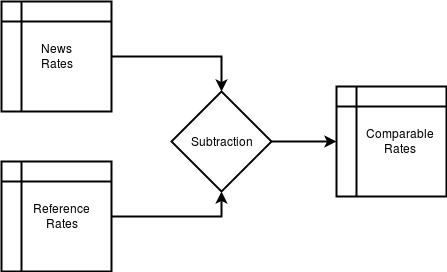

### Rates computation

- Rows represent documents and columns represent subjective dimensions

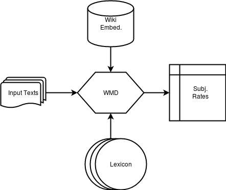

## Approaches

- Translating Lexicons
- Translating News Articles

## Validation Idea

- Is the subjectivity of informative and opinative news significantly different?
- Each confidence interval represents the difference between the subjectivity rates of opinative and informative news articles.

## First approach: Lexicons Translation

In this approach we translate the lexicons from portuguese to a target language and calculate the distance between articles and its correspondent lexicon. We use: deepL.com and https://en.pons.com/translate

### EventRegistry data

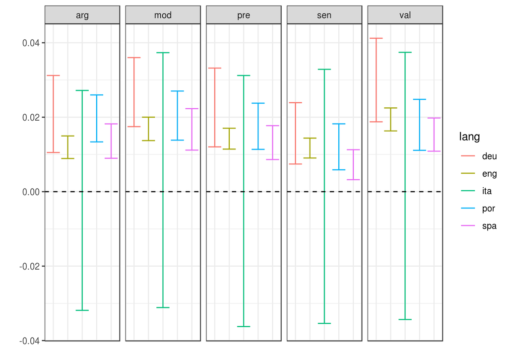

### Webhose data

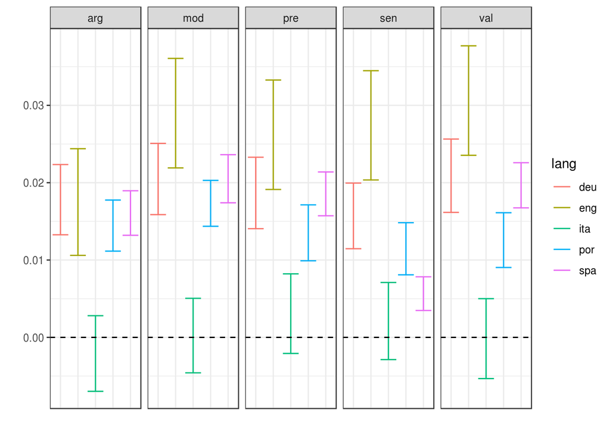

## Second Approach: News Translation

In this approach we translate the news from its original language to portuguese and calculate the distance between articles and portuguese lexicons. The news articles were manually translated using google.translate.

### EventRegistry Dataset

- 202 translated news articles

```
## # A tibble: 8 x 3
## # Groups:   lang [4]
##   lang  opinative     n
##   <chr> <lgl>     <dbl>
## 1 deu   FALSE        30
## 2 deu   TRUE         11
## 3 eng   FALSE        30
## 4 eng   TRUE         30
## 5 ita   FALSE        30
## 6 ita   TRUE         11
## 7 spa   FALSE        30
## 8 spa   TRUE         30
```

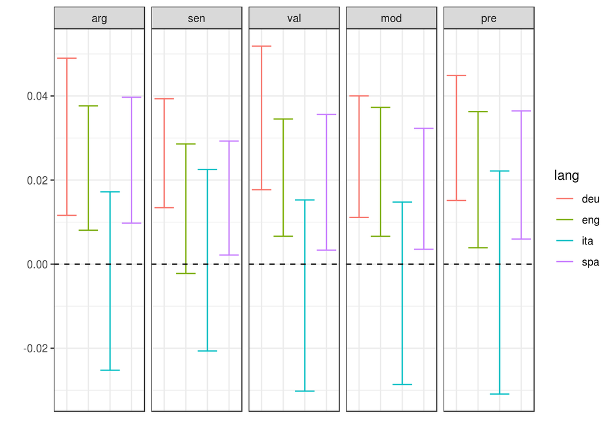

### Webhose data

- 240 translated news articles

```
## # A tibble: 8 x 3
## # Groups:   lang [4]
##   lang  opinative     n
##   <chr> <lgl>     <dbl>
## 1 deu   FALSE        30
## 2 deu   TRUE         30
## 3 eng   FALSE        30
## 4 eng   TRUE         30
## 5 ita   FALSE        30
## 6 ita   TRUE         30
## 7 spa   FALSE        30
## 8 spa   TRUE         30
```

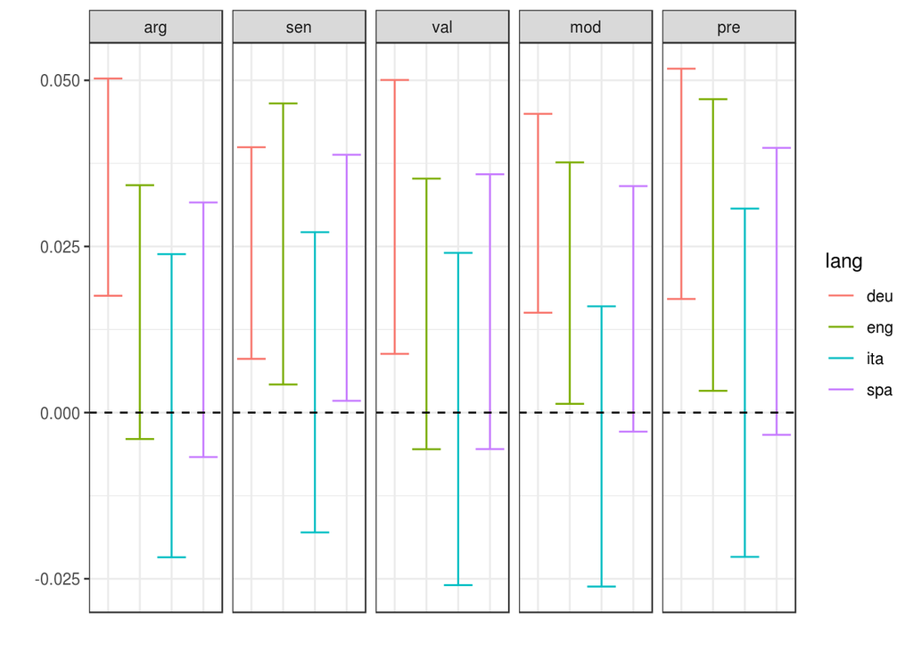

## News Translation x Lexicon Translation

Goal: Verifying whether the subjectivity levels are significantly different between the approaches

### Difference between the approaches subjectivities rates with 99% of confidence level

Each confidence interval represents the difference between the subjectivity rates of the two approaches

#### EventRegistry

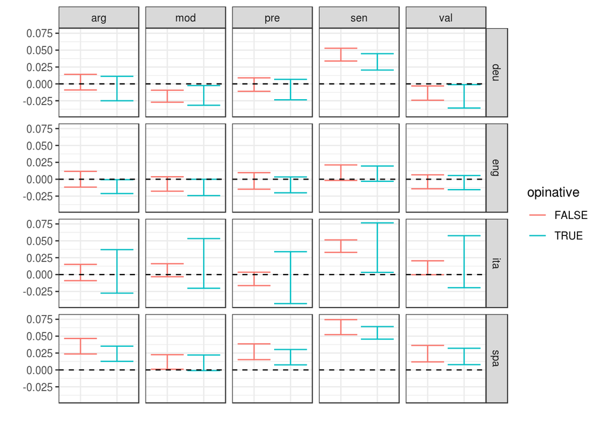

## Correlation EventRegistry: News Translations x Lexicon Translation

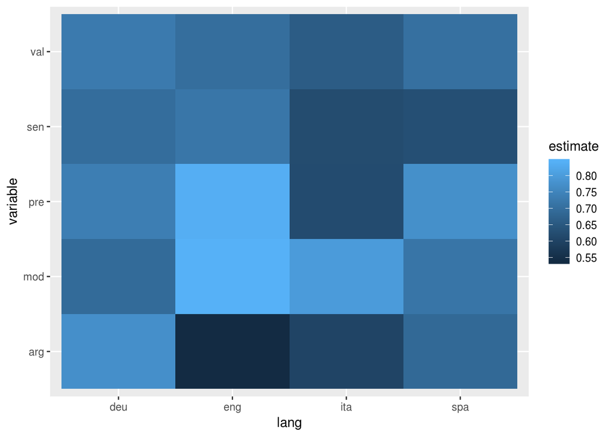

## Correlation Webhose: News Translations x Lexicon Translation

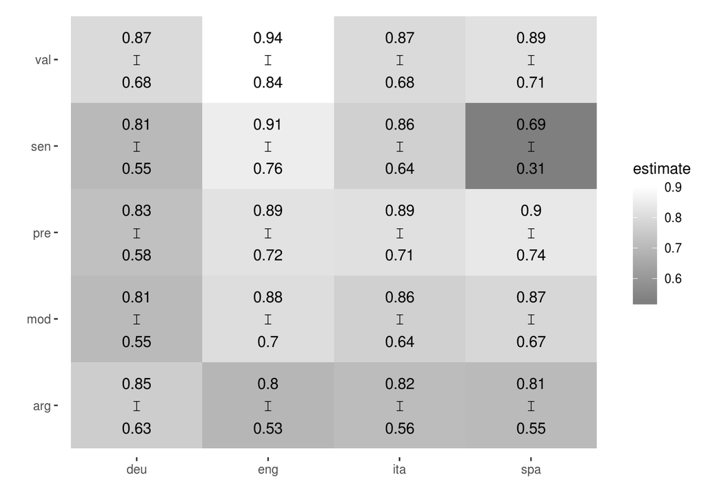